# The Pareto Distribution: Heavy Tails, Broken Inference, and the 80/20 Rule

Author

Jyotishka Datta

Published

September 10, 2026

# 1 Overview

In the previous notes we learned to generate random variables by inverting the CDF, and to estimate expectations by Monte Carlo averaging, justified by the Law of Large Numbers and the Central Limit Theorem. This note is a cautionary tale about that last step. The CLT is not a law of nature that always applies — it has a hypothesis (a finite variance), and when that hypothesis fails, the tidy standard-error machinery quietly breaks.

The **Pareto distribution** is the classic setting where this happens. It is the textbook model for income, wealth, city sizes, and file sizes, and it is where Vilfredo Pareto’s famous “80/20 rule” comes from. It also has no built-in generator in R, so it is a natural showcase for inverse-transform sampling. We develop its properties, then use simulation to watch normal-theory confidence intervals fail, and finish with the 80/20 rule.

**NotePrerequisites from the previous notes**

We use the inverse-transform sampler (to generate Pareto draws from `runif()`), the empirical CDF, and the Monte Carlo idea of estimating a quantity by averaging over many simulated samples.

# 2 The Pareto Distribution

The (Type I) Pareto distribution has a **scale** parameter $x_m > 0$ — a floor below which no values occur — and a **shape** parameter $\alpha > 0$, called the **tail index**. For $x \ge x_m$,

$$f(x) = \frac{\alpha\, x_m^{\alpha}}{x^{\alpha+1}},
\qquad
F(x) = 1 - \left(\frac{x_m}{x}\right)^{\alpha},
\qquad
S(x) = 1 - F(x) = \left(\frac{x_m}{x}\right)^{\alpha}.$$

The density is strictly decreasing, so the **mode** sits at the left edge $x_m$, and the **median** is $x_m\, 2^{1/\alpha}$. Inverting the CDF gives the quantile function — the object we feed uniform draws into to simulate:

$$F^{-1}(u) = x_m\,(1-u)^{-1/\alpha}, \qquad u \in [0,1).$$

## 2.1 Moments, and When They Exist

The defining feature of the Pareto is that **its moments can be infinite**. The $k$-th moment is finite only when the shape exceeds $k$:

$$\mathbb{E}[X^k] = \frac{\alpha\, x_m^{k}}{\alpha - k}
\quad (\alpha > k),
\qquad \text{and diverges when } \alpha \le k.$$

Specializing gives the mean and variance:

| Quantity | Formula | Finite only when |
| --- | --- | --- |
| Mean $\mathbb{E}[X]$ | $\dfrac{\alpha\, x_m}{\alpha - 1}$ | $\alpha > 1$ |
| Variance $\operatorname{Var}(X)$ | $\dfrac{\alpha\, x_m^{2}}{(\alpha-1)^2(\alpha-2)}$ | $\alpha > 2$ |
| $k$-th moment | $\dfrac{\alpha\, x_m^{k}}{\alpha - k}$ | $\alpha > k$ |

Empirically, income has a tail index around $\alpha \in (1.5, 3)$ and wealth near $1.5$, so real data routinely lands in the range $1 < \alpha < 2$: **the mean exists but the variance is infinite.** Hold on to that fact — it is what wrecks the confidence intervals below.

## 2.2 Two Structural Properties

**The tail is scale-free.** Conditioning on exceeding any threshold $t \ge x_m$ returns another Pareto with the *same* shape $\alpha$:

$$P(X > x \mid X > t) = \left(\frac{t}{x}\right)^{\alpha}, \qquad x \ge t.$$

Taking logs of the survival function, $\log S(x) = \alpha \log x_m - \alpha \log x$, shows that a Pareto tail is a **straight line of slope** $-\alpha$ on log-log axes. That straight line is the visual fingerprint of a power law, and the reason $\log(X/x_m) \sim \text{Exponential}(\alpha)$ — which in turn is what makes the Hill estimator $\hat\alpha = 1/\overline{\log(x_i/x_m)}$ the natural way to estimate the tail index.

## 2.3 Generating Pareto Draws

Because base R has no `rpareto()`, we build one by inverting the CDF exactly as in the inverse-transform notes: solving $u = F(x)$ gives $x = x_m/(1-u)^{1/\alpha}$.

```r
set.seed(3504)

## Inverse-CDF sampler for Pareto(xm, alpha)
## CDF:  F(x) = 1 - (xm/x)^alpha,  x >= xm
## Solve u = F(x)  ->  x = xm / (1 - u)^(1/alpha)
rpareto <- function(n, xm, alpha) {
  u <- runif(n)
  xm / (1 - u)^(1 / alpha)
}

## True CDF, for checking the sampler
ppareto <- function(x, xm, alpha) ifelse(x < xm, 0, 1 - (xm / x)^alpha)
```

As a sanity check, we generate “income” data above a $30{,}000 floor with $\alpha = 2$ and confirm the empirical CDF of the draws matches the true CDF.

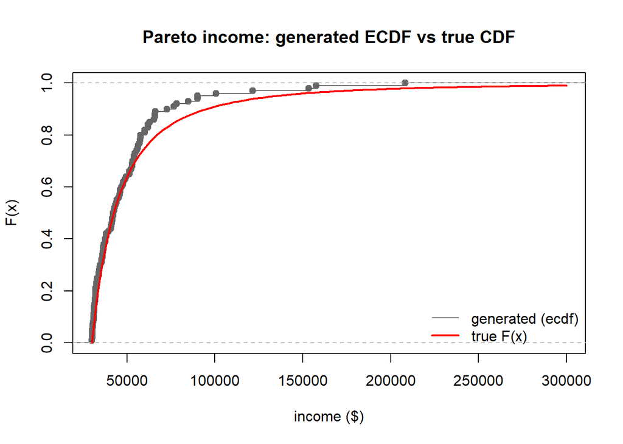

Figure 1: Empirical CDF of 100 simulated Pareto incomes (grey steps) against the true Pareto CDF (red). The close agreement confirms the inverse-transform sampler is correct.

```r
xm    <- 30000   # income floor (scale parameter)
alpha <- 2       # tail index (smaller alpha = heavier tail = more inequality)

income <- rpareto(100, xm, alpha)

plot(ecdf(income), xlim = c(xm, 3e5), col = "grey40",
     main = "Pareto income: generated ECDF vs true CDF",
     xlab = "income ($)", ylab = "F(x)")
curve(ppareto(x, xm, alpha), add = TRUE, col = "red", lwd = 2)
legend("bottomright", c("generated (ecdf)", "true F(x)"),
       col = c("grey40", "red"), lwd = c(1, 2), bty = "n")
```

# 3 When Normal-Theory Inference Breaks

Here is the payoff. Recall the standard 95% confidence interval for a mean,

$$\bar{X} \pm 1.96\,\frac{s}{\sqrt{n}},$$

whose justification is the CLT: $\bar{X}$ is approximately normal with standard error $\sigma/\sqrt{n}$, estimated by $s/\sqrt{n}$. But the CLT **requires a finite variance**. Take $\alpha = 1.5$: the mean exists and equals

$$\mathbb{E}[X] = \frac{\alpha\, x_m}{\alpha - 1}
= \frac{1.5 \times 30000}{0.5} = 90000,$$

but the variance is infinite. The sample standard deviation $s$ is then estimating something that does not exist, so the interval is built on sand. Let us see how badly it fails by simulation — exactly the kind of Monte Carlo study from the previous notes.

First, look at the sampling distribution of the sample mean over 5000 simulated samples of size $n = 200$.

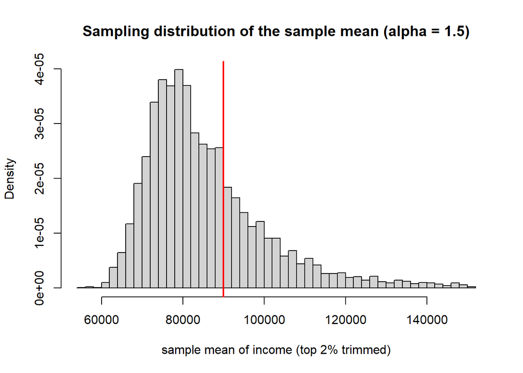

Figure 2: Sampling distribution of the sample mean for Pareto(30000, 1.5) with n = 200, over 5000 replications (top 2% trimmed for legibility). The red line marks the true mean of 90000. Instead of a symmetric bell, the distribution is strongly right-skewed.

```r
alpha_h   <- 1.5
n         <- 200
reps      <- 5000
true_mean <- alpha_h * xm / (alpha_h - 1)   # = 90000

means <- replicate(reps, mean(rpareto(n, xm, alpha_h)))

## Trim the top 2% only so the long tail does not swamp the plot
m_plot <- means[means <= quantile(means, 0.98)]
hist(m_plot, breaks = 40, probability = TRUE,
     main = "Sampling distribution of the sample mean (alpha = 1.5)",
     xlab = "sample mean of income (top 2% trimmed)")
abline(v = true_mean, col = "red", lwd = 2)
```

Even at $n = 200$, the sampling distribution is nowhere near the symmetric bell the CLT promises for well-behaved data: it is sharply right-skewed, with a heavy tail of samples whose mean is dragged far above the truth by a single enormous observation. The estimator is still unbiased — the average of these sample means is the true 90000 — but “unbiased” is cold comfort when the distribution is this skewed.

Now the consequence for the confidence interval. We build the textbook 95% interval on each of the 5000 samples and record how often it actually covers the true mean.

```r
covered <- replicate(reps, {
  x  <- rpareto(n, xm, alpha_h)
  ci <- mean(x) + c(-1, 1) * 1.96 * sd(x) / sqrt(n)
  ci[1] <= true_mean & true_mean <= ci[2]
})

mean(covered)   # nominal coverage is 0.95
```

```
[1] 0.7264
```

The empirical coverage comes out **well below the nominal 0.95**. The interval that is supposed to catch the true mean 95% of the time misses far more often than advertised, because the skewed, heavy-tailed sampling distribution makes the symmetric normal interval both mis-centered and too short. Reporting that interval would systematically overstate your confidence.

**WarningThe lesson**

The formula $\bar{X} \pm 1.96\, s/\sqrt{n}$ does not announce when it is lying. Its validity rests on a finite variance, and for heavy-tailed data like income or wealth that assumption can silently fail. This is a central motivation for the nonparametric and resampling methods in this course: rank-based summaries (like the median) and the bootstrap remain trustworthy where the normal-theory mean does not. When in doubt about the tail, **simulate the coverage** rather than trust the formula.

# 4 The 80/20 Rule (the Pareto Principle)

Pareto’s original observation was that a small share of the population holds a large share of the income. The Pareto distribution reproduces this exactly, and we can say precisely which $\alpha$ gives the famous “80/20” split.

Fix a threshold $t \ge x_m$. Two fractions matter: the share of the **population** above $t$, which is the survival function

$$p = S(t) = \left(\frac{x_m}{t}\right)^{\alpha},$$

and the share of **total income** earned above $t$, which (integrating $x f(x)$ above $t$ and dividing by the mean) works out to

$$w = \left(\frac{x_m}{t}\right)^{\alpha - 1}.$$

Both depend on the threshold through the same base $x_m/t$, so eliminating $t$ gives a scale-free relationship between the two shares:

$$\boxed{\,w = p^{\,1 - 1/\alpha}\,}.$$

The income share of the richest fraction $p$ depends **only** on the tail index. Setting $p = \tfrac{1}{5}$ (top 20%) and $w = \tfrac{4}{5}$ (80% of income) and solving gives the exact tail index of the classic rule:

$$\frac{4}{5} = \left(\frac{1}{5}\right)^{1 - 1/\alpha}
\quad\Longrightarrow\quad
\alpha = \frac{\ln 5}{\ln 4} \approx 1.161.$$

```r
inc <- rpareto(1e5, xm, alpha = log(5) / log(4))
cut <- quantile(inc, 0.80)                 # the 80th percentile threshold
sum(inc[inc >= cut]) / sum(inc)            # share of income held by the top 20%
```

```
[1] 0.7466977
```

# 5 Key Takeaways

- The **Pareto distribution** $f(x) = \alpha x_m^{\alpha}/x^{\alpha+1}$ ($x \ge x_m$) is the standard heavy-tailed model for income and wealth; it has no base-R generator, so we sample it by inverting its CDF, $x = x_m/(1-u)^{1/\alpha}$.
- Its $k$-th moment is finite **only if** $\alpha > k$: the mean needs $\alpha > 1$ and the variance needs $\alpha > 2$. Real income and wealth often sit in $1 < \alpha < 2$, where the mean exists but the variance is infinite.
- With infinite variance the **CLT fails**, and the textbook interval $\bar{X} \pm 1.96\, s/\sqrt{n}$ under-covers: our simulation shows coverage well below the nominal 95%. This motivates rank-based and resampling methods.
- On log-log axes a Pareto tail is a **straight line of slope** $-\alpha$, the fingerprint of a power law and the basis of the Hill tail-index estimator.
- The **80/20 rule** is exact: the income share of the top fraction $p$ is $w = p^{1 - 1/\alpha}$, and $\alpha = \ln 5/\ln 4 \approx 1.16$ produces the classic split where the top 20% hold 80% of income.